# UAHDataScienceUC: A Comprehensive Guide to Clustering Algorithms

Andriy Protsak

2025-02-17

The UAHDataScienceUC package provides a robust collection of clustering algorithms implemented in R. This package, developed at the Universidad de Alcalá de Henares, offers both traditional and advanced clustering methods, making it a valuable tool for data scientists and researchers. In this vignette, we’ll explore the various clustering algorithms available in the package and learn how to use them effectively.

## Installation

You can install the package from CRAN using:

```r
install.packages("UAHDataScienceUC")
```

## Available algorithms

The package implements several clustering algorithms, each with its own strengths and use cases:

- K-Means Clustering
- Agglomerative Hierarchical Clustering
- Divisive Hierarchical Clustering
- DBSCAN (Density-Based Spatial Clustering)
- Gaussian Mixture Models
- Genetic K-Means
- Correlation-Based Clustering

```r
# Load library
library(UAHDataScienceUC)

# Load data
data(db5)

# Create sample data
data <- db5[1:10, ]
```

## K-Means Clustering

It partitions n observations into k clusters where each observation belongs to the cluster with the nearest mean.

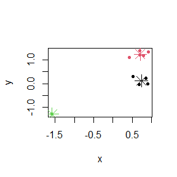

```r
# Perform k-means clustering
result <- kmeans_(data, centers = 3, max_iterations = 10)

# Plot results
plot(data, col = result$cluster, pch = 20)
points(result$centers, col = 1:3, pch = 8, cex = 2)
```

## Agglomerative Hierarchical Clustering

This algorithm builds a hierarchy of clusters from bottom-up, starting with individual observations and progressively merging them into clusters.

```r
# Perform hierarchical clustering
result <- agglomerative_clustering(
  data,
  proximity = "single",
  distance_method = "euclidean",
  learn = TRUE
)
```

```
## ________________________________________________________________________________
```

```
## EXPLANATION:
```

```
## The Agglomerative Hierarchical Clustering algorithm defines a clustering hierarc
```

```
## hy for a dataset following a `n` step process, which repeats until a single clus
```

```
## ter remains:
```

```
##     1. Initially, each object is assigned to its own cluster. The matrix of dist
```

```
##     ances between clusters is computed.
```

```
##     2. The two clusters with closest proximity will be joined together and the p
```

```
##     roximity matrix updated. This is done according to the specified proximity.
```

```
##     This step is repeated until a single cluster remains.
```

```
## The definitions of proximity considered by this function are:
```

```
##     1. `single`. Defines the proximity between two clusters as the distance betw
```

```
##     een the closest objects among the two clusters. It produces clusters where e
```

```
##     ach object is closest to at least one other object in the same cluster. It i
```

```
##     s known as SLINK, single-link or minimum-link.
```

```
##     2. `complete`. Defines the proximity between two clusters as the distance be
```

```
##     tween the furthest objects among the two clusters. It is known as CLINK, com
```

```
##     plete-link or maximum-link.
```

```
##     3. `average`. Defines the proximity between two clusters as the average dist
```

```
##     ance between every pair of objects, one from each cluster. It is also known
```

```
##     as UPGMA or average-link.
```

```
## Euclidean Distance Formula:
```

```
## d(x,y) = √(∑1ⁿ (xᵢ - yᵢ)²)
```

```
## Press [enter] to continue
```

```
## ________________________________________________________________________________
```

```
## STEP 1:
```

```
## Initially, each object is assigned to its own cluster. This leaves us with the f
```

```
## ollowing clusters:
```

```
## CLUSTER #-1 (size: 1)
##           x         y
## 1 -1.578117 -1.292868
## CLUSTER #-2 (size: 1)
##           x        y
## 2 0.7027994 1.193823
## CLUSTER #-3 (size: 1)
##           x        y
## 3 0.7854535 1.191428
## CLUSTER #-4 (size: 1)
##           x           y
## 4 0.6757613 -0.04002442
## CLUSTER #-5 (size: 1)
##           x         y
## 5 0.8484305 0.2230609
## CLUSTER #-6 (size: 1)
##          x         y
## 6 0.515489 0.3014147
## CLUSTER #-7 (size: 1)
##           x        y
## 7 0.9187371 1.347416
## CLUSTER #-8 (size: 1)
##           x           y
## 8 0.9062708 -0.01894187
## CLUSTER #-9 (size: 1)
##           x       y
## 9 0.7017478 1.37873
## CLUSTER #-10 (size: 1)
##            x        y
## 10 0.4289005 1.109321
```

```
## Press [enter] to continue
```

```
## The matrix of distances between clusters is computed:
```

```
## Distances:
##        -1    -2    -3    -4    -5    -6    -7    -8    -9
## -2  3.374
## -3  3.429 0.083
## -4  2.579 1.234 1.236
## -5  2.861 0.982 0.970 0.315
## -6  2.632 0.912 0.930 0.377 0.342
## -7  3.634 0.265 0.205 1.409 1.127 1.121
## -8  2.792 1.230 1.216 0.231 0.249 0.505 1.366
## -9  3.512 0.185 0.205 1.419 1.165 1.093 0.219 1.413
## -10 3.130 0.287 0.366 1.176 0.981 0.813 0.545 1.225 0.383
```

```
## Press [enter] to continue
```

```
## ________________________________________________________________________________
```

```
## STEP 2:
```

```
## The two clusters with closest proximity are identified:
```

```
## Clusters:
## CLUSTER #-2 (size: 1)
## CLUSTER #-3 (size: 1)
## Proximity:
## [1] 0.08268877
```

```
## Press [enter] to continue
```

```
## They are merged into a new cluster:
```

```
## CLUSTER #1 (size: 2) [CLUSTER #-2 + CLUSTER #-3]
```

```
## Press [enter] to continue
```

```
## The proximity matrix is updated. To do so the rows/columns of the merged cluster
```

```
## s are removed, and the rows/columns of the new cluster are added:
```

```
## Distances:
##        -1    -4    -5    -6    -7    -8    -9   -10
## -4  2.579
## -5  2.861 0.315
## -6  2.632 0.377 0.342
## -7  3.634 1.409 1.127 1.121
## -8  2.792 0.231 0.249 0.505 1.366
## -9  3.512 1.419 1.165 1.093 0.219 1.413
## -10 3.130 1.176 0.981 0.813 0.545 1.225 0.383
## 1   3.374 1.234 0.970 0.912 0.205 1.216 0.185 0.287
```

```
## Press [enter] to continue
```

```
## ________________________________________________________________________________
```

```
## STEP 3:
```

```
## The two clusters with closest proximity are identified:
```

```
## Clusters:
## CLUSTER #-9 (size: 1)
## CLUSTER #1 (size: 2)
## Proximity:
## [1] 0.1849095
```

```
## Press [enter] to continue
```

```
## They are merged into a new cluster:
```

```
## CLUSTER #2 (size: 3) [CLUSTER #-9 + CLUSTER #1]
```

```
## Press [enter] to continue
```

```
## The proximity matrix is updated. To do so the rows/columns of the merged cluster
```

```
## s are removed, and the rows/columns of the new cluster are added:
```

```
## Distances:
##        -1    -4    -5    -6    -7    -8   -10
## -4  2.579
## -5  2.861 0.315
## -6  2.632 0.377 0.342
## -7  3.634 1.409 1.127 1.121
## -8  2.792 0.231 0.249 0.505 1.366
## -10 3.130 1.176 0.981 0.813 0.545 1.225
## 2   3.374 1.234 0.970 0.912 0.205 1.216 0.287
```

```
## Press [enter] to continue
```

```
## ________________________________________________________________________________
```

```
## STEP 4:
```

```
## The two clusters with closest proximity are identified:
```

```
## Clusters:
## CLUSTER #-7 (size: 1)
## CLUSTER #2 (size: 3)
## Proximity:
## [1] 0.2051747
```

```
## Press [enter] to continue
```

```
## They are merged into a new cluster:
```

```
## CLUSTER #3 (size: 4) [CLUSTER #-7 + CLUSTER #2]
```

```
## Press [enter] to continue
```

```
## The proximity matrix is updated. To do so the rows/columns of the merged cluster
```

```
## s are removed, and the rows/columns of the new cluster are added:
```

```
## Distances:
##        -1    -4    -5    -6    -8   -10
## -4  2.579
## -5  2.861 0.315
## -6  2.632 0.377 0.342
## -8  2.792 0.231 0.249 0.505
## -10 3.130 1.176 0.981 0.813 1.225
## 3   3.374 1.234 0.970 0.912 1.216 0.287
```

```
## Press [enter] to continue
```

```
## ________________________________________________________________________________
```

```
## STEP 5:
```

```
## The two clusters with closest proximity are identified:
```

```
## Clusters:
## CLUSTER #-4 (size: 1)
## CLUSTER #-8 (size: 1)
## Proximity:
## [1] 0.2314716
```

```
## Press [enter] to continue
```

```
## They are merged into a new cluster:
```

```
## CLUSTER #4 (size: 2) [CLUSTER #-4 + CLUSTER #-8]
```

```
## Press [enter] to continue
```

```
## The proximity matrix is updated. To do so the rows/columns of the merged cluster
```

```
## s are removed, and the rows/columns of the new cluster are added:
```

```
## Distances:
##        -1    -5    -6   -10     3
## -5  2.861
## -6  2.632 0.342
## -10 3.130 0.981 0.813
## 3   3.374 0.970 0.912 0.287
## 4   2.579 0.249 0.377 1.176 1.216
```

```
## Press [enter] to continue
```

```
## ________________________________________________________________________________
```

```
## STEP 6:
```

```
## The two clusters with closest proximity are identified:
```

```
## Clusters:
## CLUSTER #-5 (size: 1)
## CLUSTER #4 (size: 2)
## Proximity:
## [1] 0.2488189
```

```
## Press [enter] to continue
```

```
## They are merged into a new cluster:
```

```
## CLUSTER #5 (size: 3) [CLUSTER #-5 + CLUSTER #4]
```

```
## Press [enter] to continue
```

```
## The proximity matrix is updated. To do so the rows/columns of the merged cluster
```

```
## s are removed, and the rows/columns of the new cluster are added:
```

```
## Distances:
##        -1    -6   -10     3
## -6  2.632
## -10 3.130 0.813
## 3   3.374 0.912 0.287
## 5   2.579 0.342 0.981 0.970
```

```
## Press [enter] to continue
```

```
## ________________________________________________________________________________
```

```
## STEP 7:
```

```
## The two clusters with closest proximity are identified:
```

```
## Clusters:
## CLUSTER #-10 (size: 1)
## CLUSTER #3 (size: 4)
## Proximity:
## [1] 0.2866377
```

```
## Press [enter] to continue
```

```
## They are merged into a new cluster:
```

```
## CLUSTER #6 (size: 5) [CLUSTER #-10 + CLUSTER #3]
```

```
## Press [enter] to continue
```

```
## The proximity matrix is updated. To do so the rows/columns of the merged cluster
```

```
## s are removed, and the rows/columns of the new cluster are added:
```

```
## Distances:
##       -1    -6     5
## -6 2.632
## 5  2.579 0.342
## 6  3.130 0.813 0.970
```

```
## Press [enter] to continue
```

```
## ________________________________________________________________________________
```

```
## STEP 8:
```

```
## The two clusters with closest proximity are identified:
```

```
## Clusters:
## CLUSTER #-6 (size: 1)
## CLUSTER #5 (size: 3)
## Proximity:
## [1] 0.342037
```

```
## Press [enter] to continue
```

```
## They are merged into a new cluster:
```

```
## CLUSTER #7 (size: 4) [CLUSTER #-6 + CLUSTER #5]
```

```
## Press [enter] to continue
```

```
## The proximity matrix is updated. To do so the rows/columns of the merged cluster
```

```
## s are removed, and the rows/columns of the new cluster are added:
```

```
## Distances:
##      -1     6
## 6 3.130
## 7 2.579 0.813
```

```
## Press [enter] to continue
```

```
## ________________________________________________________________________________
```

```
## STEP 9:
```

```
## The two clusters with closest proximity are identified:
```

```
## Clusters:
## CLUSTER #6 (size: 5)
## CLUSTER #7 (size: 4)
## Proximity:
## [1] 0.8125336
```

```
## Press [enter] to continue
```

```
## They are merged into a new cluster:
```

```
## CLUSTER #8 (size: 9) [CLUSTER #6 + CLUSTER #7]
```

```
## Press [enter] to continue
```

```
## The proximity matrix is updated. To do so the rows/columns of the merged cluster
```

```
## s are removed, and the rows/columns of the new cluster are added:
```

```
## Distances:
##      -1
## 8 2.579
```

```
## Press [enter] to continue
```

```
## ________________________________________________________________________________
```

```
## STEP 10:
```

```
## The two clusters with closest proximity are identified:
```

```
## Clusters:
## CLUSTER #-1 (size: 1)
## CLUSTER #8 (size: 9)
## Proximity:
## [1] 2.578678
```

```
## Press [enter] to continue
```

```
## They are merged into a new cluster:
```

```
## CLUSTER #9 (size: 10) [CLUSTER #-1 + CLUSTER #8]
```

```
## Press [enter] to continue
```

```
## The proximity matrix is updated. To do so the rows/columns of the merged cluster
```

```
## s are removed, and the rows/columns of the new cluster are added:
```

```
## Distances:
## dist(0)
```

```
## Press [enter] to continue
```

```
## ________________________________________________________________________________
```

```
## RESULTS:
```

```
## Since all clusters have been merged together, the final clustering hierarchy is:
```

```
## (Check the plot for the dendrogram representation of the hierarchy)
```

```
## Press [enter] to continue
```

```
## ________________________________________________________________________________
```

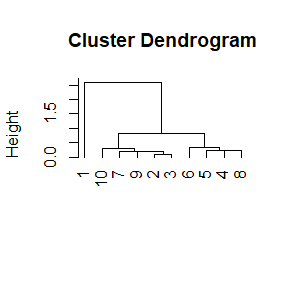

## DBSCAN

DBSCAN (Density-Based Spatial Clustering of Applications with Noise) is particularly effective at finding clusters of arbitrary shape and identifying noise points.

```r
result <- dbscan(
  data,
  epsilon = 0.3,
  min_pts = 4,
  learn = TRUE
)
```

```
## ________________________________________________________________________________
```

```
## EXPLANATION:
```

```
## The data given by data is clustered by the DBSCAN method, which aims to partitio
```

```
## n the points into clusters such that the points in a cluster are close to each o
```

```
## ther and the points in different clusters are far away from each other. The clus
```

```
## ters are defined as dense regions of points separated by regions of low density.
```

```
## The DBSCAN method follows a 2 step process:
```

```
##     1. For each point, the neighborhood of radius epsilon is computed. If the ne
```

```
##     ighborhood contains at least min_pts points, then the point is considered a
```

```
##     core point. Otherwise, the point is considered an outlier.
```

```
##     2. For each core point, if the core point is not already assigned to a clust
```

```
##     er, a new cluster is created and the core point is assigned to it. Then, the
```

```
##      neighborhood of the core point is explored. If a point in the neighborhood
```

```
##     is a core point, then the neighborhood of that point is also explored. This
```

```
##     process is repeated until all points in the neighborhood have been explored.
```

```
##      If a point in the neighborhood is not already assigned to a cluster, then i
```

```
##     t is assigned to the cluster of the core point.
```

```
## Whatever points are not assigned to a cluster are considered outliers.
```

```
## Press [enter] to continue
```

```
## ________________________________________________________________________________
```

```
## STEP 1:
```

```
## The pairwise distances between observations are precomputed in order to later de
```

```
## termine which of them are core observations. The distance matrix is:
```

```
## Distances:
##        1     2     3     4     5     6     7     8     9    10
## 1  0.000 3.374 3.429 2.579 2.861 2.632 3.634 2.792 3.512 3.130
## 2  3.374 0.000 0.083 1.234 0.982 0.912 0.265 1.230 0.185 0.287
## 3  3.429 0.083 0.000 1.236 0.970 0.930 0.205 1.216 0.205 0.366
## 4  2.579 1.234 1.236 0.000 0.315 0.377 1.409 0.231 1.419 1.176
## 5  2.861 0.982 0.970 0.315 0.000 0.342 1.127 0.249 1.165 0.981
## 6  2.632 0.912 0.930 0.377 0.342 0.000 1.121 0.505 1.093 0.813
## 7  3.634 0.265 0.205 1.409 1.127 1.121 0.000 1.366 0.219 0.545
## 8  2.792 1.230 1.216 0.231 0.249 0.505 1.366 0.000 1.413 1.225
## 9  3.512 0.185 0.205 1.419 1.165 1.093 0.219 1.413 0.000 0.383
## 10 3.130 0.287 0.366 1.176 0.981 0.813 0.545 1.225 0.383 0.000
```

```
## Press [enter] to continue
```

```
## ________________________________________________________________________________
```

```
## STEP 2:
```

```
## Every observation is labeled as UNVISITED. We are now going to loop over every o
```

```
## bservation and, if it is not already assigned to a cluster, we will try to expan
```

```
## d a new cluster around it...
```

```
## Press [enter] to continue
```

```
## ________________________________________________________________________________
```

```
## NOISE:
```

```
## An UNVISITED observation is labeled as NOISE:
```

```
## Observation #1 [UNVISITED -> NOISE]
```

```
## Press [enter] to continue
```

```
## ________________________________________________________________________________
```

```
## CLUSTER #1:
```

```
## A new cluster is going to be expanded around an UNVISITED core observation:
```

```
## Observation #2 [UNVISITED -> CLUSTER #1]
```

```
## Press [enter] to continue
```

```
## The cluster is also expanded around the neighbors of the core observation:
```

```
## Observation #3 [UNVISITED -> CLUSTER #1]
## Observation #7 [UNVISITED -> CLUSTER #1]
## Observation #9 [UNVISITED -> CLUSTER #1]
## Observation #10 [UNVISITED -> CLUSTER #1]
```

```
## All of these observations are added to the cluster.
```

```
## Press [enter] to continue
```

```
## The following core observation is expanded:
```

```
## Observation #3 [CLUSTER #1]
```

```
## It's neighborhood is:
```

```
## Observation #2 [CLUSTER #1]
## Observation #3 [CLUSTER #1]
## Observation #7 [CLUSTER #1]
## Observation #9 [CLUSTER #1]
```

```
## Upon doing it, no observations are added to the cluster...
```

```
## Additionally, no other observations are expanded...
```

```
## Press [enter] to continue
```

```
## The following core observation is expanded:
```

```
## Observation #7 [CLUSTER #1]
```

```
## It's neighborhood is:
```

```
## Observation #2 [CLUSTER #1]
## Observation #3 [CLUSTER #1]
## Observation #7 [CLUSTER #1]
## Observation #9 [CLUSTER #1]
```

```
## Upon doing it, no observations are added to the cluster...
```

```
## Additionally, no other observations are expanded...
```

```
## Press [enter] to continue
```

```
## The following core observation is expanded:
```

```
## Observation #9 [CLUSTER #1]
```

```
## It's neighborhood is:
```

```
## Observation #2 [CLUSTER #1]
## Observation #3 [CLUSTER #1]
## Observation #7 [CLUSTER #1]
## Observation #9 [CLUSTER #1]
```

```
## Upon doing it, no observations are added to the cluster...
```

```
## Additionally, no other observations are expanded...
```

```
## Press [enter] to continue
```

```
## ________________________________________________________________________________
```

```
## NOISE:
```

```
## An UNVISITED observation is labeled as NOISE:
```

```
## Observation #4 [UNVISITED -> NOISE]
```

```
## Press [enter] to continue
```

```
## ________________________________________________________________________________
```

```
## NOISE:
```

```
## An UNVISITED observation is labeled as NOISE:
```

```
## Observation #5 [UNVISITED -> NOISE]
```

```
## Press [enter] to continue
```

```
## ________________________________________________________________________________
```

```
## NOISE:
```

```
## An UNVISITED observation is labeled as NOISE:
```

```
## Observation #6 [UNVISITED -> NOISE]
```

```
## Press [enter] to continue
```

```
## ________________________________________________________________________________
```

```
## NOISE:
```

```
## An UNVISITED observation is labeled as NOISE:
```

```
## Observation #8 [UNVISITED -> NOISE]
```

```
## Press [enter] to continue
```

```
## ________________________________________________________________________________
```

```
## RESULTS:
```

```
## Having gone through every observation the following clusters have been found:
```

```
## CLUSTER #0 (NOISE):
##            x           y
## 1 -1.5781168 -1.29286766
## 4  0.6757613 -0.04002442
## 5  0.8484305  0.22306094
## 6  0.5154890  0.30141469
## 8  0.9062708 -0.01894187
```

```
## CLUSTER #1:
##            x        y
## 2  0.7027994 1.193823
## 3  0.7854535 1.191428
## 7  0.9187371 1.347416
## 9  0.7017478 1.378730
## 10 0.4289005 1.109321
```

```
## Press [enter] to continue
```

```
## ________________________________________________________________________________
```

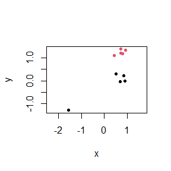